# Confidence Intervals with Bootstrap and Jackknife

László Kovács

2026-07-13

## 1. General Concept of Bootstrap Estimation

So far, dealing with confidence intervals has been relatively easy so to speak, because in the case of **maximum likelihood estimators**, we could calculate the length of the confidence interval ($\triangle$) using the standard error ($SE$) multiplied by the confidence multiplier ($k$):
$$\triangle=SE \times k$$

This formula worked because we could **provide a simple formula for the standard error of a maximum likelihood estimator** ($SE\left(\hat{\theta}_{ML}\right)=\sqrt{\mathcal{I}^{-1}}$ where $\mathcal{I}$ is the Hessian of the optimized log-likelihood function) and **calculate $k$ from the standard normal distribution**.

BUT, **what happens when these tools are NOT available?** This can happen when **the estimator of a statistical parameter cannot be obtained through maximum likelihood estimation (MLE) directly**. Some examples for this are:

1. The **estimator is not a maximum likelihood estimator**.
   - For example, we cannot obtain confidence interval for the bias **corrected standard deviation** as this is NOT a MLE
2. There is **no reasonable distribution to assume based on the observed histogram**. So we cannot say based on the histogram of the observed variable follows a lognormal, exponential, negative binomial, etc. distribution.
   - This is problematic since in this case, we **don’t have a density function to use when constructing the likelihood function**.
3. We can estimate parameters of our data distribution via maximum likelihood, but the statistical **parameter in question is too complicated to calculate from the maximum likelihood estimators**.
   - For example, in Section 7 of Chapter 4, we could easily provide a confidence interval for the median of the lognormal distribution as we simply needed to apply an $exp$ transformation on the MLE confidence interval of the $\mu$ parameter. However, getting a **confidence interval for the median of a [Beta(a, b)](https://en.wikipedia.org/wiki/Beta_distribution) distribution** would be more complicated at is needed to be expressed from the confidence intervals of both the MLEs for $a$ and $b$ with a rather complicated formula: $Me=[a-1/3]/[a+b-2/3]$

In such cases, **Bootstrap Estimation helps us**! Let’s see **the general principle of this method through the standard error of the mean**.

The standard error of the mean is obtained from a sample by taking the sample’s corrected standard deviation, $s$, and dividing it by the square root of the sample size ($n$):
$$SE(\bar{y})=\frac{s}{\sqrt{n}}$$

Let’s calculate the standard error of the mean daily internet usage time from the ess_hun_2024.xlsx dataset (`DailyNetUse` column)! Just remember that the `DailyNetUse` variable contained some missing values, so we should not consider them when determining $n$!

```r
ess <- readxl::read_excel("ess_hun_2024.xlsx")
ess_small <- ess[!is.na(ess$DailyNetUse),c("idno", "DailyNetUse")]

n <- nrow(ess_small) # this way we do not consider the empty rows

corr_std <- sd(ess_small$DailyNetUse)

SE_formula <- corr_std / sqrt(n)
SE_formula
```

```
## [1] 3.56805
```

Great, the expected deviation of the sample mean from the true population mean daily internet usage time is $\pm3.57$ minutes!

**How does this result come out using the Bootstrap method?**

The **basic idea of Bootstrap estimation comes from the standard error definition**, which we discussed in Section 2.2 of Chapter 4. We **take a very large number** (e.g., 1000 or 10000) **of replicated samples** (with replacement = IID), **calculate the mean for each sample, and the standard deviation of these sample means is the standard error and the distribution of these sample means is the sampling distribution**.  
The problem with this approach is that **in practice, we only have one single sample and do not know the full population or its true distribution, so we cannot take many IID samples from it**.  
Well, the **Bootstrap method says that we can SIMULATE this standard error and sampling distribution even from a single sample!**

If **we have a sample of size $n$, we take a very large number (e.g., 10000) of replicated sub-samples of size $n$!** Due to the **IID (with replacement) principle, the composition of these $n$-sized sub-samples will change randomly, and these random variations precisely follow the tendencies of the sampling error!!**  
After that, all we need to do is **calculate the sample mean for each sub-sample, compute the simple uncorrected standard deviation of these means, and this gives us $SE$ and the histogram of these sample means gives us the sampling distribution!!**

This idea is nicely illustrated in the following figure.

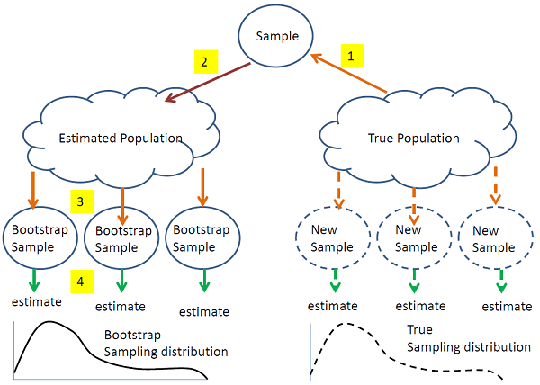

Now let’s see this in practice! **Let’s compute the standard error of the mean using the Bootstrap method!**

First, **let’s generate 10000 sub-samples of size $n=1397$ (the original $n$ sample size for internet usage times) using the `replicate` function** and store the transposed (so that the subsamples are strored in the rows) result in a new data frame.

Of course, **we should expect an increased runtime** here! :)

```r
set.seed(1992)
bootstrap_samples <- replicate(10000, sample(ess_small$DailyNetUse, size=n, replace = TRUE))
bootstrap_samples <- as.data.frame(t(bootstrap_samples))

rownames(bootstrap_samples) <- paste0("Sample",1:10000)
colnames(bootstrap_samples) <- paste0("Element",1:n)

head(bootstrap_samples)
```

|  | Element1 | Element2 | Element3 | Element4 | Element5 | Element6 | Element7 | Element8 | Element9 | Element10 | Element11 | Element12 | Element13 | Element14 | Element15 | Element16 | Element17 | Element18 | Element19 | Element20 | Element21 | Element22 | Element23 | Element24 | Element25 | Element26 | Element27 | Element28 | Element29 | … |
| --- | --- | --- | --- | --- | --- | --- | --- | --- | --- | --- | --- | --- | --- | --- | --- | --- | --- | --- | --- | --- | --- | --- | --- | --- | --- | --- | --- | --- | --- | --- |
| Sample1 | 180 | 90 | 420 | 120 | 300 | 300 | 120 | 360 | 90 | 120 | 300 | 120 | 360 | 240 | 120 | 180 | 330 | 180 | 210 | 180 | 90 | 150 | 180 | 105 | 240 | 180 | 180 | 105 | 90 | … |
| Sample2 | 240 | 300 | 150 | 360 | 180 | 300 | 270 | 120 | 90 | 90 | 60 | 60 | 60 | 330 | 120 | 15 | 60 | 120 | 300 | 90 | 150 | 390 | 120 | 60 | 180 | 90 | 180 | 300 | 360 | … |
| Sample3 | 30 | 60 | 180 | 60 | 60 | 105 | 90 | 90 | 480 | 120 | 300 | 300 | 160 | 120 | 60 | 480 | 180 | 300 | 120 | 60 | 30 | 90 | 180 | 180 | 90 | 300 | 80 | 210 | 180 | … |
| Sample4 | 180 | 40 | 120 | 260 | 120 | 240 | 50 | 120 | 120 | 330 | 120 | 150 | 300 | 300 | 160 | 180 | 240 | 180 | 120 | 170 | 180 | 60 | 180 | 300 | 120 | 120 | 240 | 210 | 60 | … |
| Sample5 | 120 | 130 | 120 | 210 | 330 | 195 | 120 | 30 | 300 | 30 | 180 | 180 | 300 | 240 | 180 | 100 | 160 | 60 | 60 | 300 | 300 | 240 | 180 | 868 | 120 | 110 | 390 | 60 | 240 | … |
| Sample6 | 60 | 360 | 180 | 180 | 80 | 140 | 180 | 90 | 300 | 300 | 115 | 240 | 60 | 110 | 120 | 90 | 180 | 90 | 210 | 40 | 90 | 240 | 90 | 300 | 90 | 60 | 90 | 100 | 30 | … |

Now we have our $10000$ bootstrap sub-samples. Let’s compute **the sample mean for each sub-sample** with the help of the `apply` function just like in Chapter 4.  
**Be careful** to always restrict statistical calculations to the first $n=1397$ columns as new columns will be added dynamically!

```r
bootstrap_samples$means <- apply(bootstrap_samples[,1:n], 1, mean)
head(bootstrap_samples[,(n-1):ncol(bootstrap_samples)]) # look at the last 3 columns
```

|  | Element1396 | Element1397 | means |
| --- | --- | --- | --- |
| Sample1 | 240 | 300 | 181.6936 |
| Sample2 | 180 | 300 | 185.1918 |
| Sample3 | 120 | 600 | 187.3601 |
| Sample4 | 150 | 180 | 191.8712 |
| Sample5 | 180 | 240 | 183.6807 |
| Sample6 | 300 | 120 | 187.6471 |

The **standard error is then simply the uncorrected standard deviation of these sub-sample means!**

```r
uncorr_sd <- function(x) {
  return(sqrt(mean((x-mean(x))^2)))
}

SE_bootstrap <- uncorr_sd(bootstrap_samples$means)
SE_bootstrap
```

```
## [1] 3.577757
```

Et voilà! Apart from some rounding error, this is approximately the same as the version obtained using $\frac{s}{\sqrt{n}}$! :)

```r
c(SE_formula, SE_bootstrap)
```

```
## [1] 3.568050 3.577757
```

Obviously, **if we take more sub-samples, the approximation becomes more accurate**. This is formally called **increasing the number of Bootstrap replications**. :) That is, the **number of replications refers to the number of sub-samples**.

BUT, **what was the point of calculating this $SE$ in such a complicated way instead of using the formula?**  
Well, **in the case of the mean, ABSOLUTELY NOTHING!**  
However, using this **Bootstrap principle, we can compute the standard error of the median daily internet usage time WITHOUT assuming that the internet usage times follow a lognormal distribution**. We’ve seen with the Q-Q Plots in Section 4.2 of Chapter 1 that the lognormal distribution is a “*good enough*” fit on the internet usage time distributions, but the $\chi^2$ goodness-of-fit test in Section 7.1 of Chapter 5 concluded that the lognormal distribution is significantly different from the observed daily internet usage time distribution on all common significance levels. So, it is a good enough fit, but has its issues. So, it would be good if we could get a $SE$ on the median without assuming this lognormal distribution, and the Bootstrap method can do just that! :)

```r
sample_median <- median(ess_small$DailyNetUse)
sample_median
```

```
## [1] 150
```

```r
bootstrap_samples$medians <- apply(bootstrap_samples[,1:n], 1, median)
SE_median <- uncorr_sd(bootstrap_samples$medians)
SE_median
```

```
## [1] 4.466131
```

Thus, we know that in the observed sample of size $n=1397$, the median daily internet usage time is **150 minutes**, and from the **standard error, we can determine that this value is expected to differ from the true median daily internet usage time of the entire Hungarian population by $\pm 4.47$ minutes**.

From here, it is just one more step to construct a **confidence interval for the median** with a confidence level of $1-\alpha$ using the Bootstrap method!

## 2. Bootstrap Confidence Interval for the Median

To determine the confidence interval of the median with confidence level $1-\alpha$ based on the $10000$ bootstrap samples, we simply need to **take the $\alpha/2$ and $1-\alpha/2$ percentiles of the 10000 median values calculated from the sub-samples**!  
After all, the $1-\alpha$ confidence interval should indicate the range within which the true population median falls with $1-\alpha$ probability. For example, in the **case of the mean, we determined this by taking the middle $1-\alpha$ percentage of the distribution of many sample means, specifically of the $N\left(\mu, \frac{\sigma}{\sqrt{n}}\right)$ distribution!!**  
With **Bootstrap** sampling, we aimed to **simulate the distribution of many sample medians**, so we should **take the middle $1-\alpha$ percentage of these simulated medians**! This is given by the $\alpha/2$ and $1-\alpha/2$ percentiles of the sub-sample median values.

Let’s examine the result for the $95\%$ confidence interval of the median internet usage time! In R, we can apply the `quantile` function on the `medians` column of our simulated data frame.  
Since $1-\alpha=95\%=0.95$, we have $\alpha=0.05=5\%$ in this case.

```r
alpha <- 0.05
quantile(bootstrap_samples$medians, probs = c(alpha/2, 1-alpha/2))
```

```
##  2.5% 97.5%
##   138   150
```

Thus, the **median daily internet usage time in the entire Hungarian population is between $138$ and $150$ minutes** with $95\%$ probability.

From the result, we can see that the confidence interval for the median is **NOT symmetric around the sample median (which was also $150$ minutes, just like the upper bound here), unlike the confidence interval for the maximum likelihood estimators, which were always symmetric around the specific maximum likelihood estimate**!

This is due to the fact that the **distribution of sample medians is not a nice, symmetric normal distribution like that of sample means or maximum likelihood estimators from large sample sizes**. This becomes immediately apparent when looking at the histograms of simulated sample means and medians.

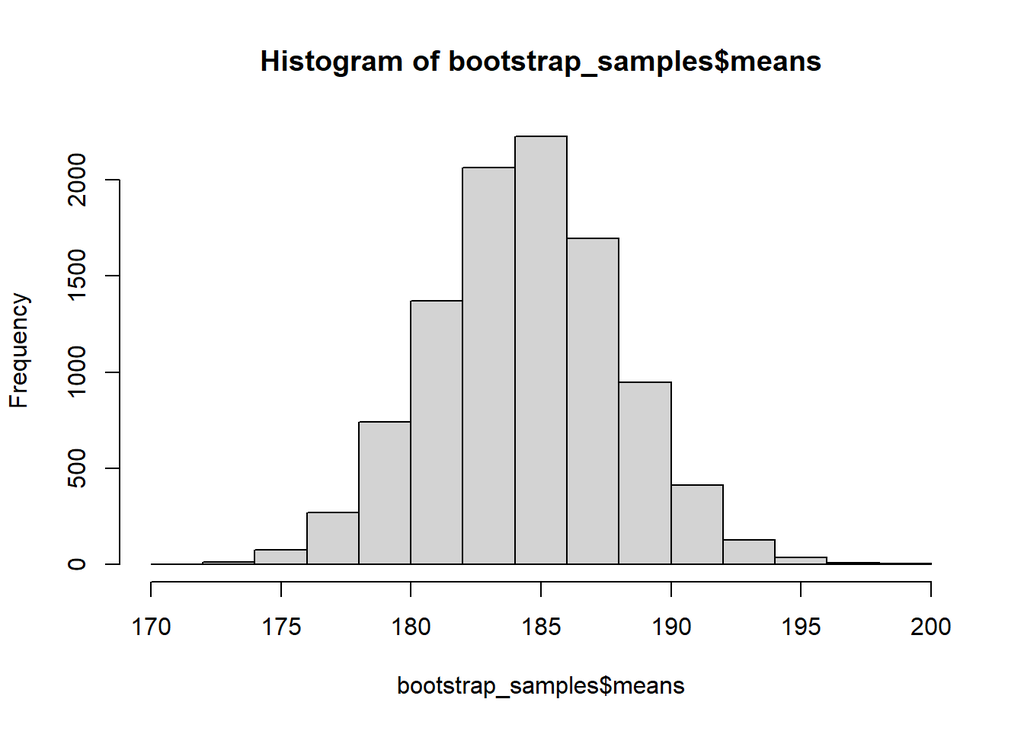

```r
hist(bootstrap_samples$means)
```

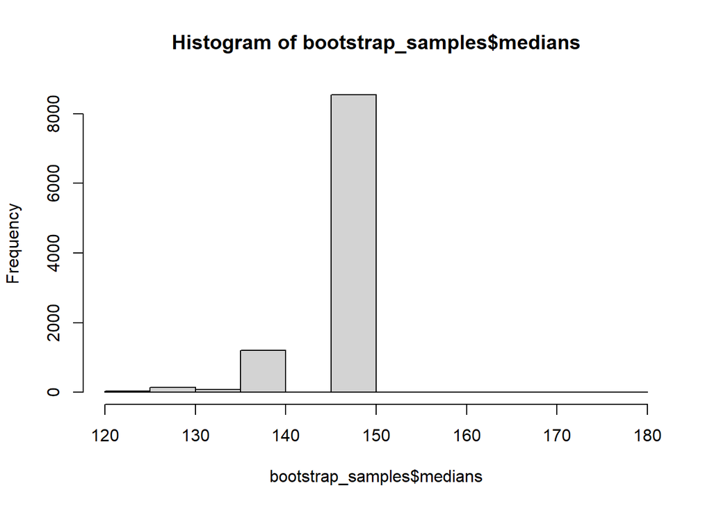

```r
hist(bootstrap_samples$medians)
```

And indeed: in the case of medians, the simulated sampling distribution is highly concentrated around $150$ with a bit of a left-tail, whereas in the case of the mean, we obtain our well-known, beautifully normal distribution! :)

By the way, we can also check that **for the mean, the $95\%$ confidence interval calculated using the bootstrap method gives the same result (with minor rounding errors) as the confidence interval calculated using the standard normal confidence multiplier**. Since in this case $n=1397$ is a large sample, it doesn’t matter whether we use the normal distribution multiplier or the t-distribution multiplier.

```r
c(mean(ess_small$DailyNetUse) - SE_formula * qnorm(1-alpha/2),
  mean(ess_small$DailyNetUse) + SE_formula * qnorm(1-alpha/2)) # Mean CI with classic formula
```

```
## [1] 177.3919 191.3784
```

```r
quantile(bootstrap_samples$means, probs = c(alpha/2, 1-alpha/2)) # Boostrap version
```

```
##     2.5%    97.5%
## 177.4657 191.4574
```

Indeed, there is only a minimal difference between the two results, which can be further reduced by increasing the number of Bootstrap sub-samples, i.e., increasing the replication number.

Fortunately, **Bootstrap confidence intervals** do not always have to be computed in such a laborious manner in R as we just did by generating a separate data frame with the `replicate` function for the sub-samples. Instead, **the `boot` package provides a built-in function named very creatively as `boot`.** An additional advantage of this function is that **its runtime performance is much better than our manually constructed solution**. This is because multiple developers have optimized the entire code behind it over several months.

Let’s install and include the package to our R environment.

```r
install.packages("boot")
library(boot)
```

The `boot` function within this package works with the following parameters:

1. We provide the **dataset in `vector` format, from which the bootstrap sub-samples** should be **generated**.
2. We specify the **statistical parameter for which we want** to compute **the confidence interval** in R.
- Here, we need to define a separate special function that calculates the statistical parameter we want on a bootstrap sub-sample. This function must be have as follows. The two input parameters are the observed data in vector format and the vector of indices that are selected into the current sub-sample. The function should return the value of the statistical measure calculated on the input data vector filtered by the indices that are selected in the sub-sample provided in the second parameter.
3. The **number of replications** can be adjusted via the `R` parameter, but since the function defaults to generating $10000$ samples, it is **generally not necessary to manually modify this parameter**. The $10000$ replications are usually sufficient. :)

Let’s see the function in action for the $95\%$ confidence interval of the median daily internet usage time!

```r
bootMedian <- function(data, indices) median(data[indices])

set.seed(1992)
boot_result <- boot(ess_small$DailyNetUse, bootMedian, R=10000)
boot_result
```

```
##
## ORDINARY NONPARAMETRIC BOOTSTRAP
##
##
## Call:
## boot(data = ess_small$DailyNetUse, statistic = bootMedian, R = 10000)
##
##
## Bootstrap Statistics :
##     original  bias    std. error
## t1*      150 -1.6559    4.387644
```

E voilá! We have the previously seen standard error of around $4.4$ minutes! :)

The bootstrap confidence intervals of any level can be obtained by applying the `boot.ci` function on the results coming from the `boot` function. In the `type` parameter, we specify that the system should **determine the confidence interval using percentiles**, just as we manually did. And here we have the $138-150$ minute confidence interval.

```r
boot.ci(boot_result, conf = 0.95, type = "perc")
```

```
## BOOTSTRAP CONFIDENCE INTERVAL CALCULATIONS
## Based on 10000 bootstrap replicates
##
## CALL :
## boot.ci(boot.out = boot_result, conf = 0.95, type = "perc")
##
## Intervals :
## Level     Percentile
## 95%   (138, 150 )
## Calculations and Intervals on Original Scale
```

## 3. Bootstrap Confidence Interval for the Bias Corrected Standard Deviation

In Bachelor level Statistics courses, a **confidence interval formula for the bias corrected standard deviation** (which is not a maximum likelihood estimator!) is covered **in the special case** when the variable in question follows a **normal distribution**.

This closed-form formula for the confidence interval of the standard deviation with confidence level $1-\alpha$ looks quite simple:
$$P\left(\sqrt{\frac{(n-1)s^2}{\chi^2_{\alpha/2}(n-1)}}<
\sigma <\sqrt{\frac{(n-1)s^2}{\chi^2_{1-\alpha/2}(n-1)}}\right) = 1 -
\alpha$$

In this formula, the only unknown term is $\chi^2(n-1)$. This is present because the corrected sample variance follows a $\chi^2$ distribution with $n-1$ degrees of freedom, just as the sample mean follows a $t$-distribution with $n-1$ degrees of freedom when the population standard deviation is not known in advance.  
The $\chi^2(k)$ distribution is a **distribution with a long right tail**. The **degree of this skewness is controlled by the degrees of freedom** ($k$): the **higher the degrees of freedom, the less skewed the distribution**.

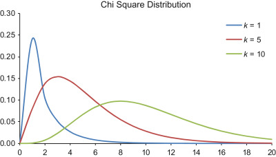

The values $\chi^2_{\alpha/2}(n-1)$ and $\chi^2_{1-\alpha/2}(n-1)$ are the **quantile functions corresponding to the probabilities $\alpha/2$ and $1-\alpha/2$** for a $\chi^2$ distribution with $n-1$ degrees of freedom (sample size minus one). Computing these values in R is very straightforward since there is a built-in function for this, logically named `qchisq`, following the naming conventions of functions for the normal, exponential, and $t$-distributions. The first parameter of this function is the known cumulative probability, and the second is the degrees of freedom, just like in `qt`.

The confidence interval is then computed by taking the sample size minus one times the corrected sample variance $(n-1)s^2$ and dividing it by $\chi^2_{1-\alpha/2}(n-1)$ for the lower bound and by $\chi^2_{\alpha/2}(n-1)$ for the upper bound, then taking the square root of the entire fraction.

Let’s apply this method to **determine the $97\%$ confidence interval for the standard deviation of daily internet usage times**!  
From a technical perspective, remember that $\chi^2_{\alpha/2}(n-1)$ gives the smaller inverse value, so it should be used in the denominator of the upper bound (to increase the result), while $\chi^2_{1-\alpha/2}(n-1)$ gives a higher inverse value, so it should be used in the denominator of the lower bound (to decrease the result).

```r
s <- sd(ess_small$DailyNetUse) # get corrected sample standard deviation
s
```

```
## [1] 133.3611
```

```r
# Get the confidence interval
n <- nrow(ess_small)
alpha <- 1-0.97

chisq_low <- qchisq(alpha/2, df = (n-1))
chisq_upp <- qchisq(1-alpha/2, df = (n-1))

common_numerator = (n-1)*(s^2)

c(sqrt(common_numerator/chisq_upp), sqrt(common_numerator/chisq_low))
```

```
## [1] 128.0955 139.0658
```

Thus, in the observed sample, the standard deviation of daily internet usage times is $133.4$ minutes, and **for the entire Hungarian population, it is likely between $128.1$ and $139.1$ minutes with $97\%$ probability**.

It is worth noting that the **confidence interval is NOT symmetric around the sample standard deviation $s$, like the confidence interval for the mean was symmetric around the sample mean**! The sample standard deviation ($s$) is somewhat closer to the lower bound of the confidence interval than to the upper bound! This occurs **because the $\chi^2$ distribution has a long right tail**, meaning that it assumes smaller values are more typical in the distribution of sample variances, so it **places the observed sample standard deviation ($s$) “towards the bottom” of the confidence interval**.

This is all well and good, but **this $\chi^2$-based confidence interval formula assumes that the variable from which the sample was taken** (i.e., daily internet usage times) **follows a normal distribution in the population!!!** However, **this assumption does NOT hold, as a quick histogram** (and our memories from the previous chapters :)) **reveals!**

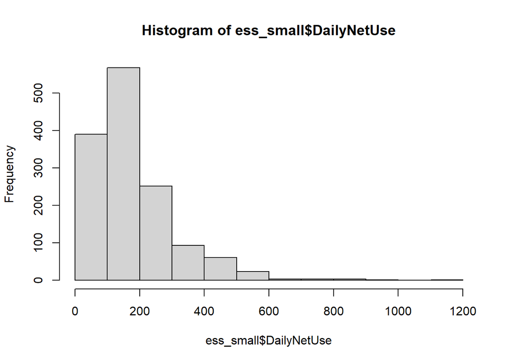

```r
hist(ess_small$DailyNetUse)
```

This time distribution has a steep **long right tail**. Therefore, in **no scenario** will this variable becomes a **nicely symmetric normal distribution** in the population!

Thus, the **confidence interval formula for the standard deviation does not provide realistic results for the true population standard deviation because the underlying assumption of normality is NOT met!**  
What can be done? We should **apply the Bootstrap estimation method, as it does not require any strict assumptions**. The only requirement is that the original population sampling should be IID, but as we discussed in Section 1 of Chapter 1, this assumption holds for the ESS2024 sample.

So, let’s perform Bootstrap estimation for the standard deviation of daily internet usage times with $97\%$ confidence level! With the built-in function from the `boot` package, we can easily accomplish this, just as we did for the median.

```r
boot_sd <- function(data, indices) sd(data[indices])

set.seed(1992)
boot_sd_result <- boot(ess_small$DailyNetUse, boot_sd, R = 10000)
boot.ci(boot_sd_result, conf = 0.97, type = "perc")
```

```
## BOOTSTRAP CONFIDENCE INTERVAL CALCULATIONS
## Based on 10000 bootstrap replicates
##
## CALL :
## boot.ci(boot.out = boot_sd_result, conf = 0.97, type = "perc")
##
## Intervals :
## Level     Percentile
## 97%   (123.0, 144.3 )
## Calculations and Intervals on Original Scale
```

Based on this, the **standard deviation of daily internet usage times in the entire Hungarian population is likely between $123.0$ and $144.3$ minutes with $97\%$ probability**. This is significantly different from the $\chi^2$-based confidence interval of $128.1$ to $139.1$ minutes, but the **Bootstrap version is more realistic because it does NOT assume that internet usage times follow a normal distribution in the population**!

So, Bootstrap estimation is quite powerful. For example, it **allows interval estimation for the mean even in cases of small samples** ($n\leq 30$), **when the sampled variable does NOT follow a normal distribution in the population and the true population standard deviation is UNKNOWN**.”

[figure not shown]

## 4. Bootstrap for Regression Models

In case of a multiple regression model $y_i=\beta_0+\beta_1x_{1i}+...+\beta_kx_{ki}+\epsilon_i$, **if** our $\beta_j$ regression **coefficient estimates are not maximum likelihood estimates and the Gauss-Markov assumptions don’t hold**, then the coefficient standard errors, p-values and confidence intervals are becoming invalid and not to be used to make any inference about the significance of explanatory variable effects on the target.  
In order **to save at least our confidence intervals** for the $\beta_j$ coefficients in an unfortunate case like this, we can **apply Bootstrap** simulations.

As a practical example, let’s return to the COVID-19 mortality data one last time from Prelude 5.

The data file used was COVID_Deaths_Hungary.csv that stores data on 5 variables (columns) for 102 Hungarian districts (those where hospitals had average or below-average capacity utilization in 2019 according to [NEAK data](http://www.neak.gov.hu/data/cms1026624/Korhazi_agyszamkimutatas_2019.pdf)):

- **District**: Name of the district
- **DeathsCOVID**: COVID-19 mortality rate: the ratio of deaths to infected persons (%) as of 2021-03-04. Source: [atlatszo.hu](https://bit.ly/COVID-adatok)
- **Nurses**: Number of general practice nurses per 10000 inhabitants (2019) Source: HCSO
- **Unemp**: Number of registered unemployed persons per 10000 inhabitants (2019) Source: HCSO
- **WomenOlder65**: Percentage of women aged 65 and older within the residential population (2019) Source: HCSO

Let’s read the file! Luckily, it is a well-behaved *csv* file, and can be read simply with the `read.csv` function:

```r
COVID <- read.csv("COVID_Deaths_Hungary.csv")
str(COVID)
```

```
## 'data.frame':    102 obs. of  5 variables:
##  $ District    : chr  "Letenyei" "Lenti" "Zalaegerszegi" "Soproni" ...
##  $ DeathsCOVID : num  5.21 3.5 3.66 2.75 4.44 4.75 5.86 4.13 3.5 5.51 ...
##  $ Nurses      : num  7.35 10.39 6.26 4.42 6.88 ...
##  $ Unemp       : num  369.1 227.4 227.4 65.5 676.7 ...
##  $ WomenOlder65: num  14.7 14.9 13.1 11.4 12.4 ...
```

Great, we still know how to read *csv* files, so congrats to ourselves! :)

After we are done with celebrations, let’s rerun the multiple regression model that predicts the COVID-19 mortality rate with **Nurses**, **Unemp** and **WomenOlder65** as explanatory (or predictor) variables.

```r
multivar_model <- lm(DeathsCOVID ~ Nurses + Unemp + WomenOlder65, data = COVID)
summary(multivar_model)
```

```
##
## Call:
## lm(formula = DeathsCOVID ~ Nurses + Unemp + WomenOlder65, data = COVID)
##
## Residuals:
##     Min      1Q  Median      3Q     Max
## -1.7695 -0.6444 -0.1815  0.3888  3.8761
##
## Coefficients:
##                Estimate Std. Error t value Pr(>|t|)
## (Intercept)  -0.1542153  0.9374402  -0.165  0.86967
## Nurses        0.0445217  0.0961260   0.463  0.64428
## Unemp         0.0028190  0.0006877   4.099 8.57e-05 ***
## WomenOlder65  0.2655669  0.0869983   3.053  0.00292 **
## ---
## Signif. codes:  0 '***' 0.001 '**' 0.01 '*' 0.05 '.' 0.1 ' ' 1
##
## Residual standard error: 1.1 on 98 degrees of freedom
## Multiple R-squared:  0.3408, Adjusted R-squared:  0.3206
## F-statistic: 16.89 on 3 and 98 DF,  p-value: 6.42e-09
```

Next, we define the function that returns the coefficients of the bootstrap sub-samples for the multiple regression model defined above.

```r
coef_boot <- function(data, indices) {
  bootstrap_model <- lm(DeathsCOVID ~ Nurses + Unemp + WomenOlder65, data = data[indices,])
  return(coef(bootstrap_model))
}
```

Apply the function with the `boot` package to get the 10000 replicated IID bootstrap sub-samples.

```r
library(boot)
boot_regression <- boot(COVID, coef_boot, R=10000)
boot_regression
```

```
##
## ORDINARY NONPARAMETRIC BOOTSTRAP
##
##
## Call:
## boot(data = COVID, statistic = coef_boot, R = 10000)
##
##
## Bootstrap Statistics :
##         original        bias     std. error
## t1* -0.154215324  4.319495e-02 0.9172832524
## t2*  0.044521687  7.055305e-03 0.1130695775
## t3*  0.002819019 -1.503745e-05 0.0005770319
## t4*  0.265566925 -6.548702e-03 0.1036664771
```

And let’s have the $97\%$ level confidence intervals via the percentiles of the simulated coefficients.

```r
boot_ci <- lapply(1:length(multivar_model$coefficients),
                  function(x) boot.ci(boot_regression,
                                      conf = 0.97, type = "perc", index = x)$percent[4:5])
names(boot_ci) <- names(multivar_model$coefficients)
boot_ci
```

```
## $`(Intercept)`
## [1] -2.057155  1.927700
##
## $Nurses
## [1] -0.1776294  0.3151566
##
## $Unemp
## [1] 0.001537759 0.004068011
##
## $WomenOlder65
## [1] 0.02629521 0.47347934
```

The results are roughly the same as the OLS (and MLE, see Section 8.1 of Chapter 4) $97\%$ confidence intervals.

```r
confint(multivar_model, level = 0.97)
```

```
##                     1.5 %      98.5 %
## (Intercept)  -2.218596448 1.910165801
## Nurses       -0.167161932 0.256205306
## Unemp         0.001304503 0.004333534
## WomenOlder65  0.073983851 0.457149999
```

This suggests that the model assumptions (Gauss-Markov or normality of $Y$) are probably met. Based on the histogram of the COVID mortality rate, the normal distribution of this target variable seems acceptable, the right tail is very moderate. So, the results obtained via maximum likelihood using normal density are rather correct, that’s why the simulated bootstrap confidence intervals are close to the ones expressed with OLS and maximum likelihood formulas.

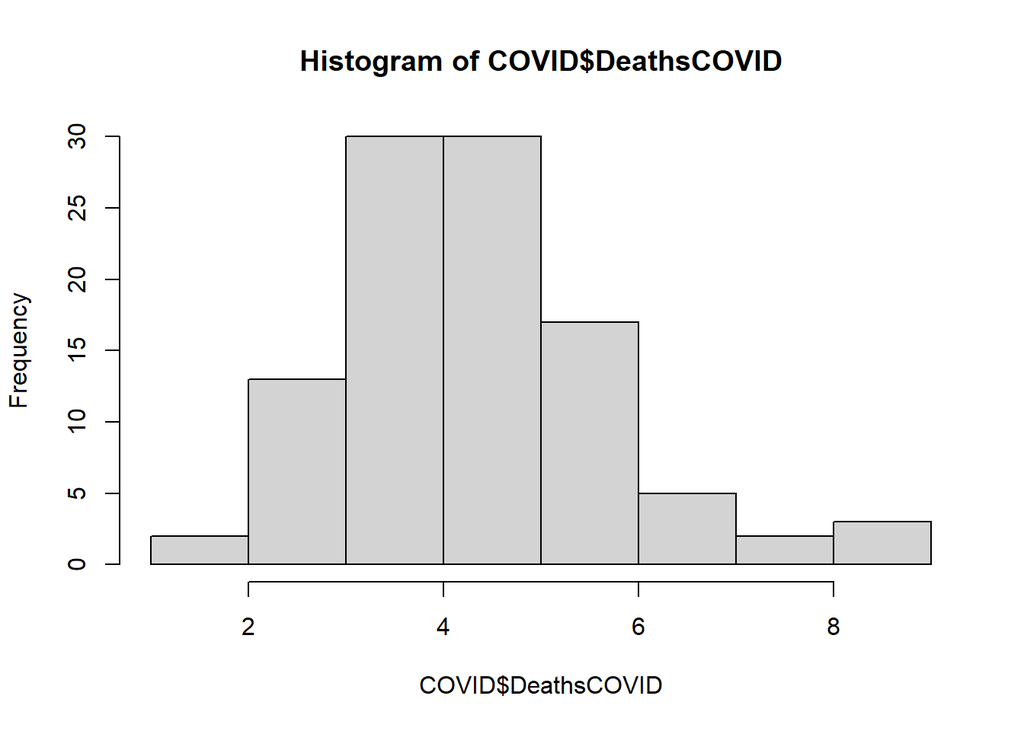

```r
hist(COVID$DeathsCOVID)
```

## 5. Parametric Bootstrap

Now, the version of the Bootstrap method **covered in Sections 1-4** is called the **Nonparametric Bootstrap**, where random sub-samples of the same size as the original data are taken from the data with replacement.

This nonparametric approach **can be problematic is small sample sizes with statistical parameters that are more complicated to calculate than a simple mean**. The reason for that is for small sample sizes the bootstrap sub-samples are as small in size as the original sample data, so the **random variability among the sub-samples**, that represents the sampling error, **won’t be as large as it should be**, since there is no room for it due to the small sizes. And this causes an **underestimation of the standard error** as the standard deviation among the bootstrap estimates of the parameter in question won’t be as large. This is because the bootstrap sub-samples with small sizes look very similar to each other as there is not enough room for the sampling with replacement to truly create random variation (i.e. the sampling error) among them. So, the bootstrap estimates of the parameter in question (the value of the parameter calculated from the bootstrap sub-samples) will look very similar to each other, hence their small standard deviation, which is an underestimation of the standard error.  
This **underestimation of standard error can be mitigated if the parameter in question is not robust to outliers like the mean**. As in these kind of statistical parameters the value can change substantially if only one observation in the sub-sample changes, so this can compensate for the bootstrap estimates being too similar in small sample sizes, as we do not need to change so much in each bootstrap sub-sample for the estimate of the parameter from it to change. So, **for the mean the nonparametric bootstrap can work rather nicely in small samples as well, but things become problematic for robust statistical measures like quantiles** for example.

To tackle this **underestimation of standard errors**, we can apply **Parametric Bootstrap**. Parametric Bootstrapping **assumes that the data comes from a known probability distribution** with unknown parameters. For example the data may come from a Poisson, Negative Binomial for discrete, or Normal, Exponential for continuous variables. We **estimate the parameters** from the observed data that we have with maximum likelihood or method of moments and then We **use the fitted distribution to simulate (in an IID way of course) the bootstrap samples** with the same size as the original data.  
With this, we lose the advantage of the original Nonparametric Bootstrap that we don’t need to assume anything on the true population distribution of our variable, but with this, we can introduce more variability in the simulated bootstrap sub-samples, therefore solving the underestimation of standard errors. Of course, this **only makes sense if we want a confidence interval for a statistical parameter that cannot be easily calculated from the maximum likelihood confidence intervals of the estimated distribution parameters**. Although, the maximum likelihood standard error formula and sampling distribution is also not very reliable in small samples, according to Section 5 of Chapter 4. An example is given in Section 1: the median of a $Beta(a,b)$ distribution.

Let’s see the following situation. Let’s assume we are sitting in an insurance company that insures the property damage of very luxurious villas for gas plumbers in Hungary. Since there are not so many villas that are appropriate for the needs of the most talented gas plumbers (like a *stable for zebras*), the company only insures $n=20$ villas.  
The names and the number of property damages reported last year for these insured villas are given in the Hatvanpuszta.xlsx file. Let’s load it to an R data frame.

```r
villas <- readxl::read_excel("Hatvanpuszta.xlsx")
head(villas) # see the first 6 rows
```

| Name | DamageNumber |
| --- | --- |
| Hatvanpuszta | 2 |
| Villa BékeZóna | 2 |
| Palace de Panellakás | 1 |
| Château Csóringó | 0 |
| Villa Hitelmentes | 1 |
| Casa del Kijött a lépés | 1 |

Great, we have the number of damages reported for each of hour $n=20$ villas starting with the best one (Hatvanpuszta). Let’s assume that the insurance company wants to know the **value which is only exceeded by the yearly number of damages 1% of the times**. In other words, they want to know the **99th percentile (P99)** of the `DamageNumber` variable: the **value below which villas have 99% of damage numbers and only 1% of damage numbers are above it**.

It’s quite easy to calculate with the `quantile` function of R, so let’s do it.

```r
quantile(villas$DamageNumber, probs = 0.99)
```

```
##  99%
## 6.43
```

It’s $P99 = 6.43$, so we have only 1% chance of finding a villa with a larger damage number in a year than 6 (number of damages can take only integers, so it is a discrete variable). Let’s see if the distribution of the yearly damage numbers confirm this. Since the `DamageNumber` variable is discrete a combination of `table` and `barplot` is needed, we don’t need the bins of a histogram here.

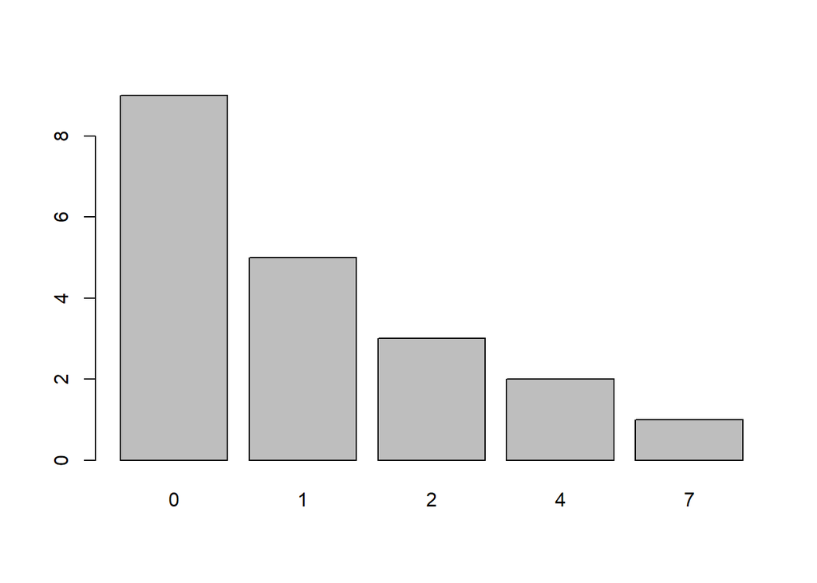

```r
barplot(table(villas$DamageNumber))
```

```r
P99_boot <- function(data, indices) quantile(data[indices], prob=0.99)

set.seed(1992)
boot_P99_result <- boot(villas$DamageNumber, P99_boot, R = 10000)
boot.ci(boot_P99_result, conf = 0.97, type = "perc")
```

```
## BOOTSTRAP CONFIDENCE INTERVAL CALCULATIONS
## Based on 10000 bootstrap replicates
##
## CALL :
## boot.ci(boot.out = boot_P99_result, conf = 0.97, type = "perc")
##
## Intervals :
## Level     Percentile
## 97%   ( 2,  7 )
## Calculations and Intervals on Original Scale
```

Ok, well **P99 can be anywhere between $2$ and $7$ with $97\%$ of confidence**. We can see that this result is heavily influenced by the fact that we had this 1 villa with 7 damages last year and the **observed data cannot imagine more damages a year than 7**. However, this **maximum of 7 can very well be due to the fact that the company only insures 20 villas and it was just lucky that they did not insure a villa with more than 7 damages last year**. This can be the case even if the villas are representatively selected from the whole population of villas. Just due to the limited number of observations (i.e. sample size) it can happen that we do not observe the highest number of damages, so the upper confidence interval of P99 is underestimated. So, we’ll try **Parametric Bootstrap to correct** for that.

To apply parametric bootstrapping, we need to **assume a theoretical distribution for the number of damages in the unobserved villa population**. Since the number of damages is a discrete variable, we need to check the relationship between the observed mean and variance and decide the distribution (Binomial, Poisson, Negative Binomial) based on that.

```r
c(mean(villas$DamageNumber), sd(villas$DamageNumber)^2)
```

```
## [1] 1.300000 3.378947
```

Since variance is way larger than the mean, the **negative binomial distribution seems like a good assumption**. As a reminder see Section 5.4 of Chapter 1.

Negative Binomial distribution has 2 parameters to estimate from the data, $r$ and $p$. These are called in R as `size` and `prob`. Using that we can do the maximum likelihood estimation for $r,p$ in R just like we did in Section 4 of Chapter 3.

```r
neg_log_likelihood_nbinom <- function(theta_nbinom){
  log_lik_observations <- log(dnbinom(x = villas$DamageNumber,
                                     size = theta_nbinom[1],
                                     prob = theta_nbinom[2]))
  return(-sum(log_lik_observations))
}

nbinom_mle <- optim(c(8, 0.1), neg_log_likelihood_nbinom)
nbinom_mle$par # the estimated parameter values
```

```
## [1] 0.8441509 0.3936082
```

Once we have a data frame containing the $10000$ bootstrap sub-samples in the rows, we can calculate P99 for every sub-sample as a new column in this data frame with the help of `apply`.  
For the $97\%$ confidence interval, we just need to take the middle $97\%$ of these simulated P99 values, so we need to find the $1.5\%$ and $98.5\%$ percentiles of these values with the help of the `quantile` function.

```r
set.seed(1992)
bootstrap_samples <- replicate(10000, rnbinom(n=length(villas),
                                              size = nbinom_mle$par[1],
                                              prob = nbinom_mle$par[2]))
bootstrap_samples <- as.data.frame(t(bootstrap_samples))

bootstrap_samples$P99 <- apply(bootstrap_samples[,1:length(villas)], 1,
                               function(x) quantile(x, prob=0.99))

alpha <- 1-0.97
quantile(bootstrap_samples$P99, probs = c(alpha/2, 1-alpha/2))
```

```
##  1.5% 98.5%
##  0.00  8.91
```

Great, we have that the $97\%$ confidence interval for this P99 is between $0$ and $8.91 \approx 9$. So, the upper bound is definitely larger than the observed maximum of 7. This means that based on our negative binomial distribution, **with $97\%$ confidence, we can very well imagine that the damage number above which only $1\%$ of villas have more damages is $9$**. Now, this high damage number is something that is more believable for Ákos Hadházy and his band of Grand Theft Auto players. :)

[figure not shown]

## 6. The Jackknife Method

Okay, so at this point we have a solution to handle Bootstrap even in the small sample size cases as well by assuming the population distribution of the observed data. What else is left to do?  
Well, the **issue with Bootstrap confidence intervals that they are computationally expensive**. To get accurate estimates, you often need tens of thousands of bootstrap sub-samples and You need to calculate your statistical parameters on every sub-sample. This can be computationally expensive, especially **when working with large data sets and with parameters that are complicated to calculate** (e.g. coefficients of a multivariate regression model that we’ll soon see in Chapter 7). Think about it, running a complex calculation on large data that takes 2 seconds on 10000 bootstrap sub-samples will take 20000 seconds that is more than 5 and a half hours! Parallel processing on expensive CPUs can help reduce this to 1-2 hours but that is still a lot! So, if your computer’s fan starts sounding like a jet engine, you might be pushing the bootstrap too hard!

A nice **alternative when Bootstrap is too expensive computationally is the Jackknife method**. It follows the **leave-one-out** approach to simulate the sampling distribution of a statistical parameter. This means that we want to **to calculate what we would get as our estimated statistical parameter if an observation were replaced by a new one and we do this with every observation we have**.

Let’s see this principle in action to get a $97\%$ confidence interval for the *bias corrected standard deviation of daily internet usage times* based on the ESS dataset! Thankfully, we already have the sufficiently filtered data frame as `ess_small` from Section 1.

Now, as a **first step**, let’s **calculate the corrected standard deviations when exactly one observation is dropped from the data**, and **loop this calculation with every observation that we have**. This way, we’ll have sample size number of estimated **partial standard deviations**, i.e. standard deviations in case when one observation is dropped from the data.

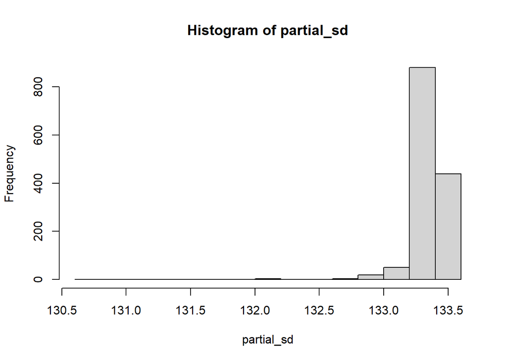

```r
sample_size <- nrow(ess_small)
partial_sd <- rep(NA, sample_size) # an empty vector with sample size number of elements to store the partial sd values

for (i in 1:sample_size) {
  partial_sd[i] <- sd(ess_small$DailyNetUse[-i])
}

hist(partial_sd)
```

Great, we have the $n=1397$ partial standard deviations, and they look quite similar to each other around the value of $133$ as the standard deviation does not really change if we leave out 1 observation, only if that 1 observation is a bit of an outlier, in that case it decreases. Hence the left-tailed distribution of these partials. However, these partial standard deviations are **just standard deviations when we leave out 1 observation, not when that 1 observation is replaced with a random other observation!** To correct for this behavior we need to **introduce so-called PSEUDOVALUES**.

The partial estimates for the standard deviation estimates are all based on samples of size $n-1$ and not $n$.  
Hence, they are slightly biased versions of the full-sample standard deviation, because removing a point changes the sample size and the estimator’s distribution. The **pseudovalues rescale and recenter the partials around the standard deviation calculated from the full sample to approximated what the standard deviation would be for a full sample of size $n$ if observation $i$ were replaced by a new one**.  
And the **jackknife estimate of the standard deviation is the mean of these pseudovalues**.

```r
full_sample_sd <- sd(ess_small$DailyNetUse)
pseudos <- (sample_size * full_sample_sd) - ((sample_size-1) * partial_sd)
jack_sd <- mean(pseudos)
jack_sd
```

```
## [1] 133.4526
```

Now, since the jackknife estimate of the bias corrected standard deviation is just a mean, we can get the **jackknife confidence interval** of $97\%$ with the general (i.e. confidence multiplier coming from t-distribution) **confidence interval formula for the mean** (introduced in Section 4 of Chapter 4) applied on the mean of the pseudovalues. So, **in the standard error formula of $s/\sqrt{n}$, we need the standard deviation of the pseudovalues as $s$!**

```r
jack_se <- sd(pseudos)/sqrt(sample_size)
alpha <- 1-0.97
length_of_CI <- qt(1-alpha/2, df=sample_size-1) * jack_se

c(jack_sd - length_of_CI,
  jack_sd + length_of_CI)
```

```
## [1] 122.7190 144.1863
```

So, the **standard deviation of daily internet usage times in the entire Hungarian population is likely between $122.7$ and $144.2$ minutes with $97\%$ probability**. This is almost exactly the **same as the nonparametric bootstrap confidence interval** we had in Section 3.  
So, **with the jackknife, we could achieve the results of a bootstrap confidence interval with way less computation** (only $n=1397$ standard deviations were calculated and NOT 10000) and **without any randomness**.

Now, let’s organize our **jackknife** calculations **as a custom R function**! We need to replace the `ess_small$DailyNetUse` with a general input `data` parameter and the `sd` function with a general input statistical function called `statistic`, and the confidence level should be set as a third input called as `conf` for example.

- `est` = jackknife estimate of the examined statistical parameter, i.e. the mean of the pseudovalues
- `se` = jackknife standard error of the jackknife estimate
- `ci` = jackknife confidence interval calculated with the confidence interval formula for the mean
- `pseudos` = vector of the $n$ pseudovalues
- `partials` = vector of the $n$ leave-one-out partial estimates of the examined statistical parameter

Let’s **write this custom function**, and use it to reproduce our $97\%$ jackknife confidence interval for the bias corrected standard deviation!

```r
jknife <- function(data, statistic, conf=0.95) {
  sample_size <- length(data) # data is assumed to be a vector, i.e. column of a data frame
  partials <- rep(NA, sample_size)

  for (i in 1:sample_size) {
    partials[i] <- statistic(data[-i])
  }

  full_sample_stat <- statistic(ess_small$DailyNetUse)
  pseudos <- (sample_size * full_sample_stat) - ((sample_size-1) * partials)
  jack_estimate <- mean(pseudos)

  jack_se <- sd(pseudos)/sqrt(sample_size)
  alpha <- 1-conf
  length_of_CI <- qt(1-alpha/2, df=sample_size-1) * jack_se

  CI <- c(jack_estimate - length_of_CI,
          jack_estimate + length_of_CI)

  return(list(est=jack_estimate,
              se=jack_se,
              ci=CI,
              pseudos=pseudos,
              partials=partials))
}

jack_result_sd <- jknife(ess_small$DailyNetUse, sd, 0.97) # testing the custom function
jack_result_sd$ci # see the confidence interval from the returned list
```

```
## [1] 122.7190 144.1863
```

Great, we have the same $97\%$ confidence interval for the corrected standard deviation as before!

Now, let’s use this new `jknife` of ours to show the **limitation of the jackknife compared to bootstrap**: it is **extremely poor for robust statistical parameters like the median** and other quantiles.  
This is perfectly understandable as **robust parameters are NOT sensitive to outliers, so leaving out one observation does not change their values**. So, we’ll have the same partial estimates, which means the pseudovalues are also the same, so they do not have any variance to calculate confidence interval from. So, the jackknife confidence interval for the median will have the same lower and upper boundaries as the median calculated from all observations.

```r
jack_result_median <- jknife(ess_small$DailyNetUse, median, 0.97) # testing the custom function
jack_result_median$ci
```

```
## [1] 150 150
```

Hmm, [f***k](https://www.youtube.com/watch?v=NYvwLLxKqhM). The confidence interval bounds are truly the same. So, there is a limit to jackknifing, and in cases like these we need that extra computational power and randomness that the bootstrap provides to obtain reliable confidence intervals!